# Statistical analysis of tissue-specific miRNA and gene expression

Yining Ding

# Libraries

- The libraries used in this notebooks are
  - ggrepel (Slowikowski 2020)
  - forcats (Wickham 2020)
  - scales (Wickham and Seidel 2019)
  - httr (Wickham 2019)
  - miRNAmeConverter (Haunsberger, Connolly, and Prehn 2016)
  - dplyr (Wickham, François, et al. 2020)
  - ggplot2 (Wickham 2016)
  - HGNChelper (Waldron and Riester 2019)
  - kableExtra (Zhu 2019)
  - biomaRt (Steffen Durinck and Huber 2009)
  - tidyverse (Wickham, Averick, et al. 2019)
  - ggpubr (Kassambara 2020)

# Helper function

- **mirDIP_filter_task_helper.R** is a file that includes functionst to define expressivity according to user’s request, and also combines all expression tables into one table with unique miRNA as row names.

```r
source("mirDIP_filter_task_helper.R")
```

# my expression tables

- The list of files calls all the known miRNA files (15 files) previously saved, and create 4 default tables with confidence levels “Very High”, “High”, “Medium” and “Low”.

```r
list_of_files <- list.files(path = "/Users/helending/Documents/BCB330/saved_expr_data/expr_data_known",
                            recursive = TRUE,
                            pattern = "final_known*",
                            full.names = TRUE)

source("mirDIP_filter_task_helper.R")
new_tables_0.99 <- call_expressivity(list_of_files, 0.99)
new_tables_0.95 <- call_expressivity(list_of_files, 0.95)
new_tables_2_3 <- call_expressivity(list_of_files, 2/3)
new_tables_1_3 <- call_expressivity(list_of_files, 1/3)
```

## Collapse all expr tables into one with different confidence levels

- Combine all the tables for each confidence levels and write to tables accordingly and save in the **data** folder. These run a long time, so I did not include the code, I have uploaded the files.

```r
# combined_all_expr_tables_0.99 <- combine_all_expr_tables(new_tables_0.99, list_of_files)
# combined_all_expr_tables_0.95 <- combine_all_expr_tables(new_tables_0.95, list_of_files)
# combined_all_expr_tables_2_3 <- combine_all_expr_tables(new_tables_2_3, list_of_files)
# combined_all_expr_tables_1_3 <- combine_all_expr_tables(new_tables_1_3, list_of_files)
#
# write.table(combined_all_expr_tables_0.99, "combined_all_expr_tables_0.99.csv")
# write.table(combined_all_expr_tables_0.95, "combined_all_expr_tables_0.95.csv")
# write.table(combined_all_expr_tables_2_3, "combined_all_expr_tables_2_3.csv")
# write.table(combined_all_expr_tables_1_3, "combined_all_expr_tables_1_3.csv")
```

## 3 tasks implemented

- **tasks_helper.R** is a file that contains all three task helper functions. Here are some working examples. For the first example, since the list of miRNA is too long, I will only show the number of miRNAs.

```r
source("tasks_helper.R")
results_one <- give_tissues_return_mir("kidney,heart", "Very High")

kable(results_one[c(1, 3)], caption = "Function 1", format="html") %>%
  kable_styling(bootstrap_options = c("stripe", "hover"))
```

Function 1

| Tissues | num_miR |
| --- | --- |
| kidney | 847 |
| heart | 845 |

```r
results_two <- give_mir_return_tissues("hsa-let-7a,hsa-let-7b", "Very High")
kable(results_two, caption = "Function 2", format="html") %>%
  kable_styling(bootstrap_options = c("stripe", "hover"))
```

Function 2

| miR | Tissues |
| --- | --- |
| hsa-let-7a |  |
| hsa-let-7b | kidney ,lung ,salivary.gland |

```r
results_three <- give_tissue_mir_return_info("kidney,heart", "hsa-let-7a,hsa-let-7b", "Very High")
kable(results_three, caption = "Function 3", format="html") %>%
  kable_styling(bootstrap_options = c("stripe", "hover"))
```

Function 3

| miR | kidney | heart |
| --- | --- | --- |
| hsa-let-7a | 0 | 0 |
| hsa-let-7b | 1 | 0 |

# Query genes associated with my miR

- Here we used the tables that combined all the expression miRNAs and query for their corresponding gnes. We found that the number of unique genes are 15536.

```r
combined_all_expr_tables <- read.table("/Users/helending/Documents/BCB330/mir_expr_table/data/combined_all_expr_tables.csv")

# query for their corresponding genes
mirs <- paste(combined_all_expr_tables$miR, collapse = ", ")
source("/Users/helending/Documents/BCB330/mir_expr_table/api.R")
mirDIP_genes <- get_mirDIP_gene(microrna_string = mirs,
                                userScore = "Very High")
```

```
No encoding supplied: defaulting to UTF-8.
```

```r
unique_mirdip <- unique(mirDIP_genes$Gene.Symbol)# length: 15536
```

# read GTEx file

```r
zz <- CePa::read.gct("/Users/helending/Documents/BCB330/gtex/data/GTEx_Analysis_2017-06-05_v8_RNASeQCv1.1.9_gene_median_tpm.gct")
gtex_data <- data.frame(zz)
nrow(gtex_data) # 56200
```

```
[1] 56200
```

# Identifier mapping for GTEx

```r
ensembl <- useMart("ensembl")
ensembl = useDataset("hsapiens_gene_ensembl",mart=ensembl)

 conversion_stash <- "gtex_id_conversion.rds"
if(file.exists(conversion_stash)){
  gtex_id_conversion <- readRDS(conversion_stash)
} else {
  gtex_id_conversion <- getBM(attributes = c("ensembl_gene_id_version","hgnc_symbol"),
                            filters = "ensembl_gene_id_version",
                            values = rownames(gtex_data),
                            mart = ensembl)
  saveRDS(gtex_id_conversion, conversion_stash)
}

# merge
gtex_data_annot <- merge(gtex_id_conversion,gtex_data,by.x = 1, by.y = 0, all.y=TRUE)
write.table(gtex_data_annot, "/Users/helending/Documents/BCB330/gtex/data/gtex_annotated.csv")

# how many unmapped?
unmapped_id <- which(is.na(gtex_data_annot$hgnc_symbol))
length(unmapped_id) # 18901
```

```r
# how many duplicated gene symbols?
gtex_data_annot_copy <- gtex_data_annot[-unmapped_id, ]
gtex_data_annot_copy <- gtex_data_annot_copy[-which(gtex_data_annot_copy$hgnc_symbol == ""), ]
nrow(gtex_data_annot_copy) # 20699
```

```r
nrow(unique(gtex_data_annot_copy)) # 20697
```

# filter GTEx as expressed / not expressed

```r
gtex_data_annot <- gtex_data_annot_copy

threshold <- 5
y <- gtex_data_annot[,3:ncol(gtex_data_annot)]
for(i in 1:nrow(y)){
  for (j in 1:ncol(y)){
    if (y[i, j] >= threshold){
      y[i, j] <- 1
    } else{
      y[i, j] <- 0
    }
  }
}
copy_y <- cbind("hgnc_symbol"=gtex_data_annot$hgnc_symbol, y)
copy_y <- cbind("ensembl_gene_id"=gtex_data_annot$ensembl_gene_id, copy_y)
write.table(copy_y, "/Users/helending/Documents/BCB330/gtex/data/filtered_gtex.csv")
```

# GTEx - corresponding tissues

```r
copy_y <- read.table("/Users/helending/Documents/BCB330/gtex/data/filtered_gtex.csv", stringsAsFactors = FALSE)
copy_y <- copy_y[which(copy_y$hgnc_symbol %in% unique_mirdip), c(1, 2, 3, 35, 36, 39, 43, 44, 46, 52)]
```

## GTEx pie graph

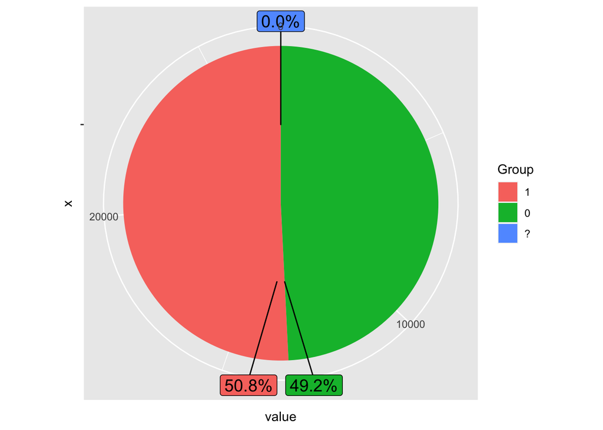

```r
unknown_sum <- length(copy_y[copy_y == "?"])
has_sum <- length(copy_y[copy_y == "1"])
no_sum <- length(copy_y[copy_y == "0"])
df_gtex <- data.frame(
  group = c("?", "1", "0"),
  value = c(unknown_sum, has_sum, no_sum))
df_gtex %>%
arrange(desc(value)) %>%
mutate(prop = percent(value / sum(value))) -> mydf_getx

ggplot(mydf_getx, aes(x = "", y = value, fill = fct_inorder(group))) +
       geom_bar(width = 1, stat = "identity") +
       coord_polar("y", start = 0) +
       geom_label_repel(aes(label = prop), size=5, show.legend = F, nudge_x = 1) +
       guides(fill = guide_legend(title = "Group"))
```

```r
rownames(copy_y) <- 1:nrow(copy_y) # 3386 genes
```

## GTEx statistics (number 1)

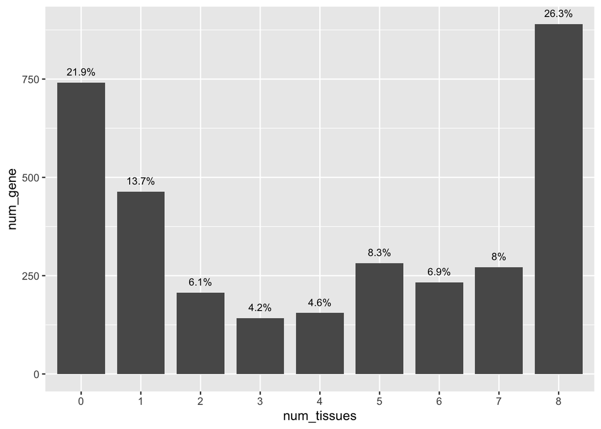

```r
# add a column
copy_y <- cbind(copy_y, "num_tissue" = rowSums(copy_y == "1"))
num_tissue_table <- data.frame(table(copy_y$num_tissue))
colnames(num_tissue_table) <- c("num_tissues", "num_gene")

num_tissue_table_percent_gtex <- num_tissue_table
num_tissue_table_percent_gtex$per <- paste0(round(num_tissue_table_percent_gtex$num_gene / sum(num_tissue_table_percent_gtex$num_gene)*100, digits = 1), '%')
rownames(num_tissue_table_percent_gtex) <- 1:nrow(num_tissue_table_percent_gtex)

# graph
ggplot(num_tissue_table_percent_gtex, aes(x = num_tissues, y = num_gene))+
  geom_text(aes(label = per), size = 3, hjust = 0.5, vjust = -1, position = "stack")+
  geom_col(width = 0.8)
```

## GTEx statistics (number 2)

```r
# add a row
copy_y <- rbind(copy_y, colSums(copy_y == "1"))
copy_y[nrow(copy_y),]
```

|  | ensembl_gene_id | hgnc_symbol | Adipose...Subcutaneous | Heart...Left.Ventricle | Kidney...Cortex | Lung | Ovary | Pancreas | Prostate | Testis | num_tissue |
| --- | --- | --- | --- | --- | --- | --- | --- | --- | --- | --- | --- |
| 3387 | 0 | 0 | 1897 | 1185 | 1450 | 1999 | 1921 | 1170 | 1968 | 2166 | 464 |

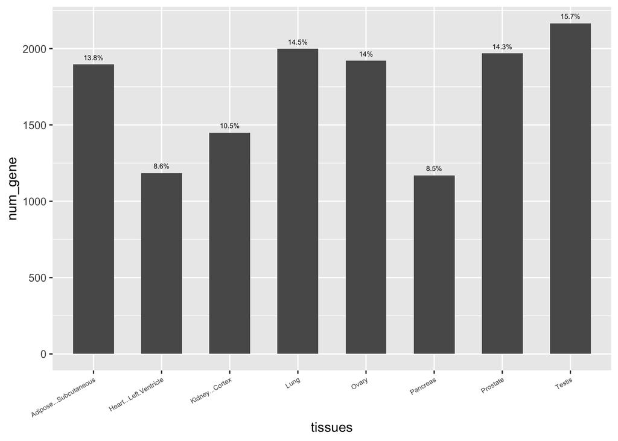

```r
# graph table
tissue_table <- data.frame("tissues"=colnames(copy_y)[2:ncol(copy_y)],
                           "num_gene"=as.numeric(copy_y[nrow(copy_y),2:ncol(copy_y)]))

tissue_table_percent_gtex <- tissue_table[c(2:9),]
tissue_table_percent_gtex$per <- paste0(round(tissue_table_percent_gtex$num_gene / sum(tissue_table_percent_gtex$num_gene)*100, digits = 1), '%')
rownames(tissue_table_percent_gtex) <- 1:nrow(tissue_table_percent_gtex)

# graph
ggplot(tissue_table_percent_gtex, aes(x = tissues, y = num_gene))+
  geom_text(aes(label = per), size = 2, hjust = 0.5, vjust = -0.9, position = "stack")+
  geom_col(width = 0.6) +
  theme(axis.text.x = element_text(angle = 30, hjust = 1, size = 5.5))
```

# IID

## gene-gene interaction

- Get IID human annotated PPIs (Kotlyar et al. 2019) genes, convert the two column gene-gene interactions into one column by copying and pasting one column to the bottom of the other column. And then we removed duplicates and write to the file: **gene_interaction_dup.csv**, and saved in the **data** folder.

```r
IID_data <- read.delim("/Users/helending/Documents/BCB330/mir_expr_table/data/human_annotated_PPIs.txt", header = TRUE, sep = "\t")
gene_interaction <- IID_data
nrow(gene_interaction) # 975877
```

```r
gene_interaction_copy <- gene_interaction
gene_interaction_copy[,c(1:4)] <- gene_interaction_copy[, c(1, 2, 4, 3)]

# bind the same table under the existing one, flip, and delete the "symbol 2" column
gene_interaction <- rbind(gene_interaction, gene_interaction_copy)

gene_interaction <- gene_interaction[,-c(1, 2, 4)]
colnames(gene_interaction)[1] <- "SYMBOLS"
gene_interaction <- gene_interaction[, -c(2, 3, 4, 5)]

# Remove duplicates
duplicated_genes <- which(duplicated(gene_interaction[1])) # 18726 unique genes
gene_interaction_dup <- gene_interaction
gene_interaction_dup <- gene_interaction_dup[-duplicated_genes,]
nrow(gene_interaction_dup) # 18726
```

```r
write.table(gene_interaction_dup, "/Users/helending/Documents/BCB330/mir_expr_table/data/gene_interaction_dup.csv")
```

## Corresponding genes and tissues in IID

- Here we retrieve corresponding genes and corresponding tissues (15 tissues that we have data for miR expression data).

```r
copy_y <- read.table("/Users/helending/Documents/BCB330/mir_expr_table/data/gene_interation_dup.csv", stringsAsFactors = FALSE)

# Only examine the 15 tissues
tissue_names <- character()
for (i in 1:length(new_tables_0.99)){
  tissue_names[i] <- colnames(new_tables_0.99[[i]])[2]
}
copy_y_copy <- copy_y[which(copy_y$SYMBOLS %in% unique_mirdip), which(colnames(copy_y) %in% tissue_names)]
```

## IID pie graph

- Here we generates an overview of the IID annotated data.

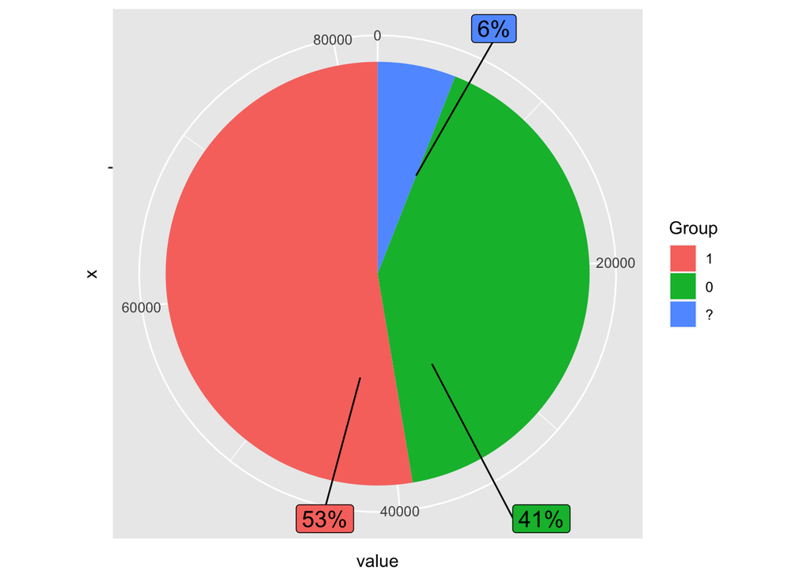

```r
unknown_sum <- length(copy_y_copy[copy_y_copy == "?"]) # 39
has_sum <- length(copy_y_copy[copy_y_copy == "1"]) # 489
no_sum <- length(copy_y_copy[copy_y_copy == "0"]) # 327
df_iid <- data.frame(
  group = c("?", "1", "0"),
  value = c(unknown_sum, has_sum, no_sum))
df_iid %>%
arrange(desc(value)) %>%
mutate(prop = percent(value / sum(value))) -> mydf

ggplot(mydf, aes(x = "", y = value, fill = fct_inorder(group))) +
       geom_bar(width = 1, stat = "identity") +
       coord_polar("y", start = 0) +
       geom_label_repel(aes(label = prop), size=5, show.legend = F, nudge_x = 1) +
       guides(fill = guide_legend(title = "Group"))
```

```r
copy_y_copy <- cbind("gene" = copy_y$SYMBOLS[which(copy_y$SYMBOLS %in% unique_mirdip)], copy_y_copy)
```

## IID statistics (number 1)

- Here we examine the general statistics of IID gene expression data by adding a column and sum rowise. The biological meaning is that we want to determine whether gene in IID are tissue specific or not by examining the number of tissues a miRNA targets.

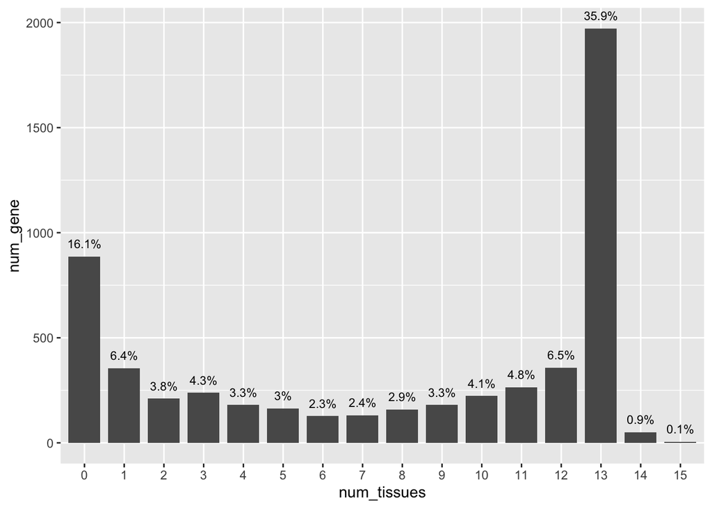

```r
# add a column
copy_y_copy <- cbind(copy_y_copy, "num_tissue" = rowSums(copy_y_copy == "1"))
num_tissue_table <- data.frame(table(copy_y_copy$num_tissue))
colnames(num_tissue_table) <- c("num_tissues", "num_gene")


num_tissue_table_percent <- num_tissue_table
num_tissue_table_percent$per <- paste0(round(num_tissue_table_percent$num_gene / sum(num_tissue_table_percent$num_gene)*100, digits = 1), '%')
rownames(num_tissue_table_percent) <- 1:nrow(num_tissue_table_percent)

# graph
ggplot(num_tissue_table_percent, aes(x = num_tissues, y = num_gene))+
  geom_text(aes(label = per), size = 3, hjust = 0.5, vjust = -1, position = "stack")+
  geom_col(width = 0.8)
```

## IID statistics (number 2)

- Here we are at the second stage of examining the overal statistics by adding a row. The biological meaning is that we want to know for each tissue, what is the number of miRNA that targets it. Therefore, getting the sense that whether the tissue contains tissue specific or generic miRNA expressions.

```r
# add a row
copy_y_copy <- rbind(copy_y_copy, colSums(copy_y_copy == "1"))
copy_y_copy[nrow(copy_y_copy),]
```

|  | gene | adipose.tissue | bone | bone.marrow | heart | kidney | lung | mammary.gland | ovary | pancreas | placenta | prostate | salivary.gland | testes | melanoma | Alzheimer.s.disease | num_tissue |
| --- | --- | --- | --- | --- | --- | --- | --- | --- | --- | --- | --- | --- | --- | --- | --- | --- | --- |
| 5499 | NA | 3367 | 3354 | 3354 | 3391 | 3290 | 3295 | 3370 | 3368 | 3345 | 3041 | 3272 | 3403 | 3408 | 97 | 67 | 354 |

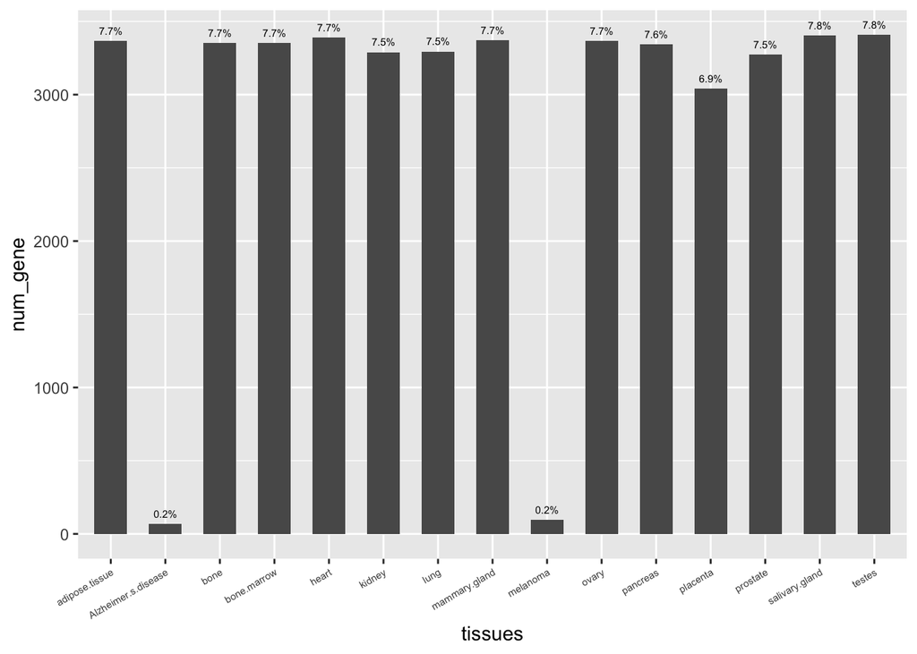

```r
# graph table
tissue_table <- data.frame("tissues"=colnames(copy_y_copy)[2:ncol(copy_y_copy)],
                           "num_gene"=as.numeric(copy_y_copy[nrow(copy_y_copy),2:ncol(copy_y_copy)]))

tissue_table_percent_iid <- tissue_table
tissue_table_percent_iid$per <- paste0(round(tissue_table_percent_iid$num_gene / sum(tissue_table_percent_iid$num_gene)*100, digits = 1), '%')
tissue_table_percent_iid <- tissue_table_percent_iid[-nrow(tissue_table_percent_iid),]
rownames(tissue_table_percent_iid) <- 1:nrow(tissue_table_percent_iid)

# graph
ggplot(tissue_table_percent_iid, aes(x = tissues, y = num_gene))+
  geom_text(aes(label = per), size = 2, hjust = 0.5, vjust = -0.9, position = "stack")+
  geom_col(width = 0.6) +
  theme(axis.text.x = element_text(angle = 30, hjust = 1, size = 5.5))
```

# miR

- We conduct the same statistical analysis in miR expression table as the IID above.

```r
all_expr <- read.table("/Users/helending/Documents/BCB330/mir_expr_table/data/combined_all_expr_tables.csv", stringsAsFactors = FALSE)
all_expr_copy <- all_expr

tissue_names <- character()
for (i in 1:length(new_tables_0.99)){
  tissue_names[i] <- colnames(new_tables_0.99[[i]])[2]
}
all_expr_copy <- all_expr[,which(colnames(all_expr_copy) %in% tissue_names)]
all_expr <- cbind("miR" = all_expr$miR, all_expr_copy)
```

## miR statistics (number 1)

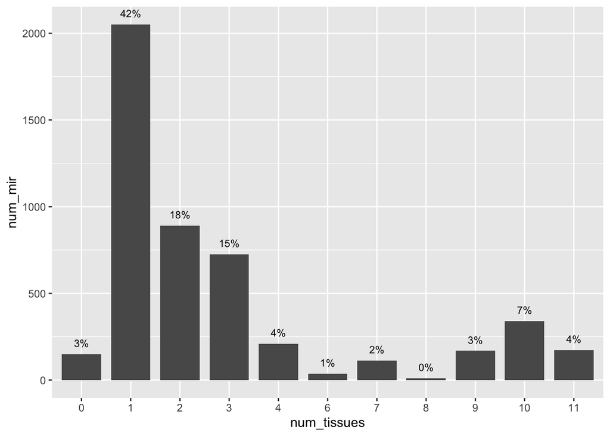

```r
# add a column
all_expr <- cbind(all_expr, "num_tissue" = rowSums(all_expr_copy == "1"))
# graph table
num_tissue_table <- data.frame(table(all_expr$num_tissue))
colnames(num_tissue_table) <- c("num_tissues", "num_mir")

num_tissue_table_percent <- num_tissue_table
num_tissue_table_percent$per <- paste0(round(num_tissue_table_percent$num_mir / sum(num_tissue_table_percent$num_mir)*100), '%')
rownames(num_tissue_table_percent) <- 1:nrow(num_tissue_table_percent)

# graph
ggplot(num_tissue_table_percent, aes(x = num_tissues, y = num_mir))+
  geom_text(aes(label = per), size = 3, hjust = 0.5, vjust = -1, position = "stack")+
  geom_col(width = 0.8)
```

## miR statistics (number 2)

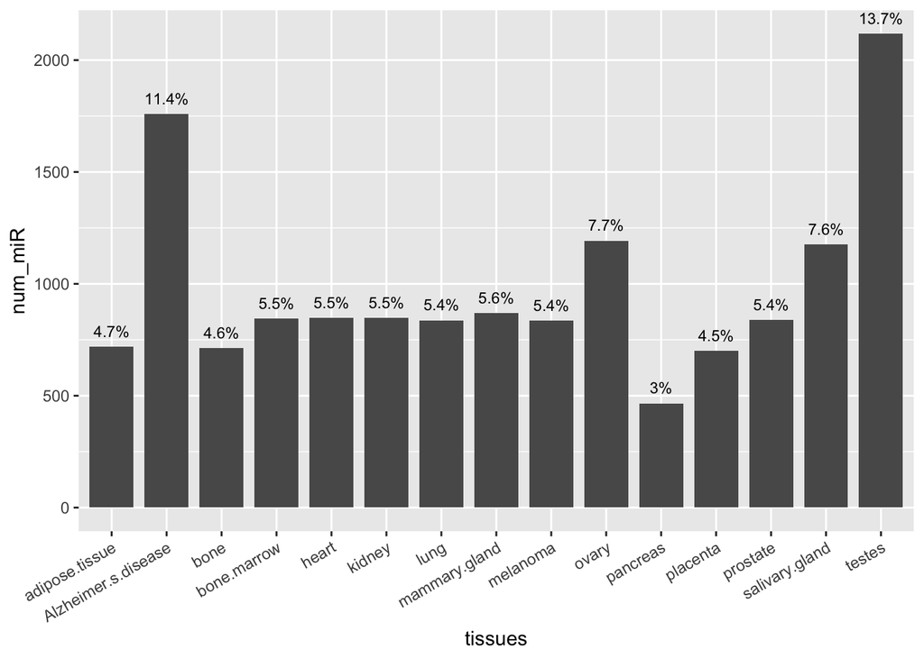

```r
# add a row
all_expr <- rbind(all_expr, colSums(all_expr_copy == "1"))
tissue_table <- data.frame("tissues"=colnames(all_expr)[2:ncol(all_expr)],
                           "num_miR"=as.numeric(all_expr[nrow(all_expr),2:ncol(all_expr)]))

tissue_table_percent <- tissue_table
tissue_table_percent$per <- paste0(round(tissue_table_percent$num_miR / sum(tissue_table_percent$num_miR)*100, digits = 1), '%')
tissue_table_percent <- tissue_table_percent[-nrow(tissue_table_percent),]
rownames(tissue_table_percent) <- 1:nrow(tissue_table_percent)

# graph
ggplot(tissue_table_percent, aes(x = tissues, y = num_miR))+
  geom_text(aes(label = per), size = 3, hjust = 0.5, vjust = -0.9, position = "stack")+
  geom_col(width = 0.8) +
  theme(axis.text.x = element_text(angle = 30, hjust = 1))
```

## miR statistics (number 3)

Using qqplot to examine whether the data are normally distributed.

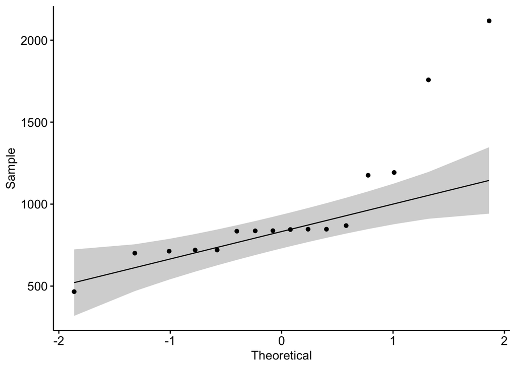

```r
ggqqplot(tissue_table$num_miR)
```

# Combine IID and miR

- We compare IID gene expression and miRNA expression.

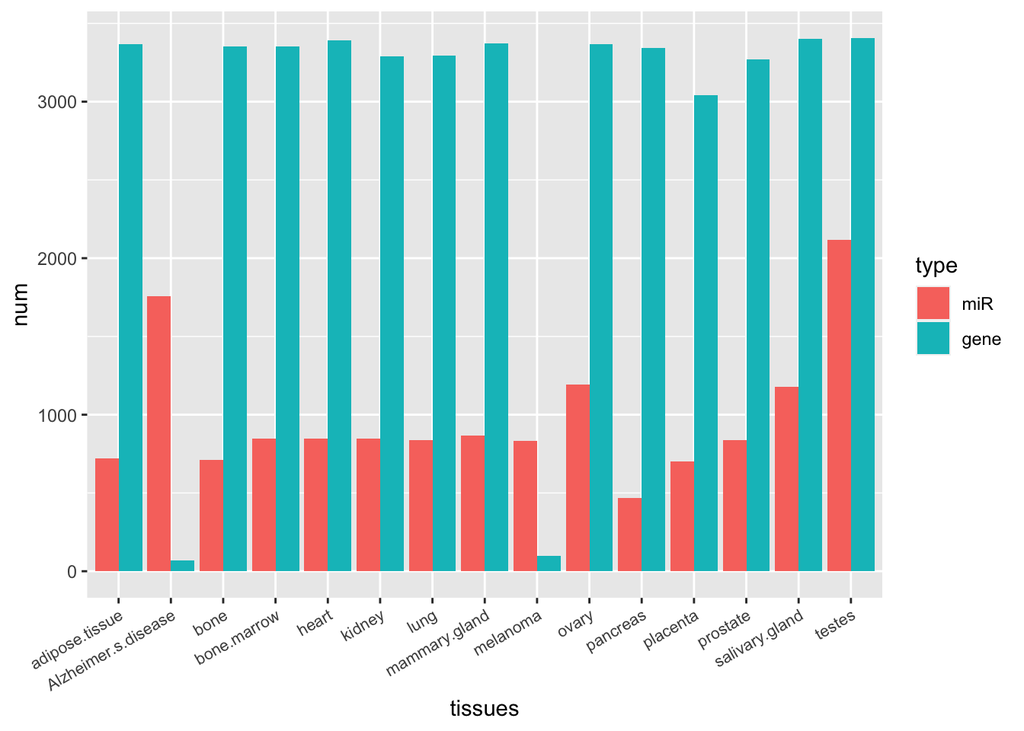

```r
tissue_table_percent_iid <- cbind(tissue_table_percent_iid, "type"="gene")
colnames(tissue_table_percent_iid)[2] <- "num"
tissue_table_percent <- cbind(tissue_table_percent, "type"="miR")
colnames(tissue_table_percent)[2] <- "num"


tissue_table_percent <- rbind(tissue_table_percent, tissue_table_percent_iid)
tissue_table_percent$num <- as.numeric(as.character(tissue_table_percent$num))

# graph
ggplot(tissue_table_percent, aes(tissues, num, fill = type)) +
  geom_bar(position="dodge", stat="identity") +
  theme(axis.text.x = element_text(angle = 30, hjust = 1, size = 8))
```

## Combine getx and miR (number 1)

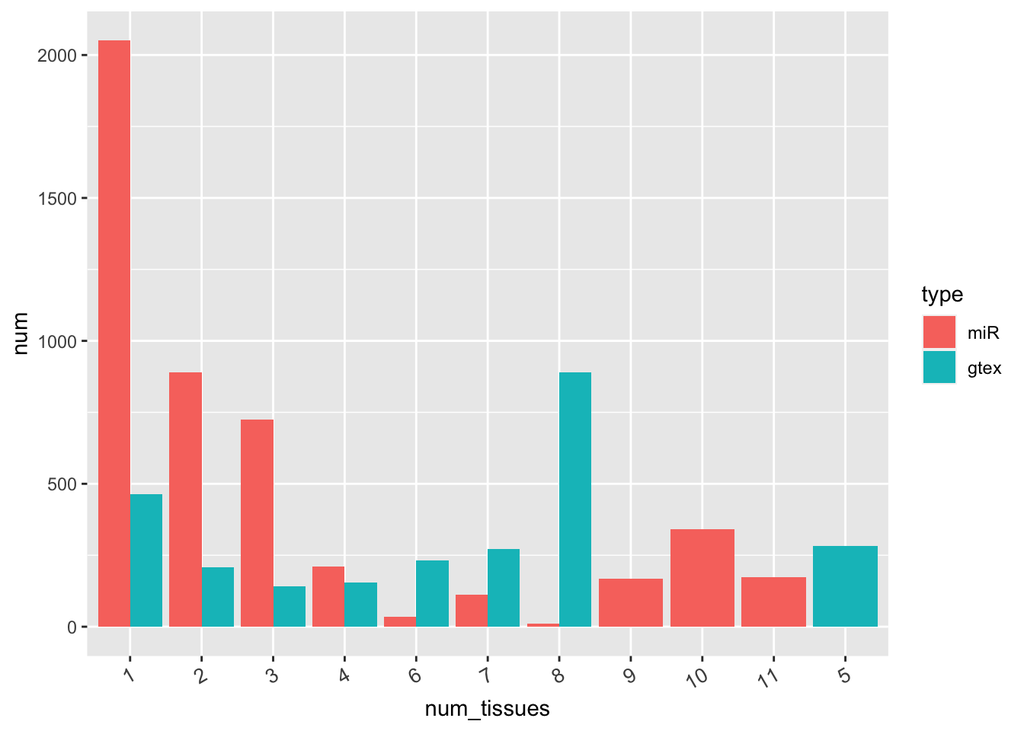

```r
num_tissue_table_percent_gtex <- cbind(num_tissue_table_percent_gtex,"type"="gtex")
num_tissue_table_percent<- cbind(num_tissue_table_percent, "type"="miR")
colnames(num_tissue_table_percent)[2] <- "num"
colnames(num_tissue_table_percent_gtex)[2] <- "num"
num_tissue_table_percent <- rbind(num_tissue_table_percent, num_tissue_table_percent_gtex)
num_tissue_table_percent$num <- as.numeric(as.character(num_tissue_table_percent$num))
num_tissue_table_percent <- num_tissue_table_percent[-which(num_tissue_table_percent$num_tissues ==0),]

ggplot(num_tissue_table_percent, aes(num_tissues, num, fill = type)) +
  geom_bar(position="dodge", stat="identity") +
  theme(axis.text.x = element_text(angle = 30, hjust = 1, size = 10))
```

## Combine getx and miR (number 2)

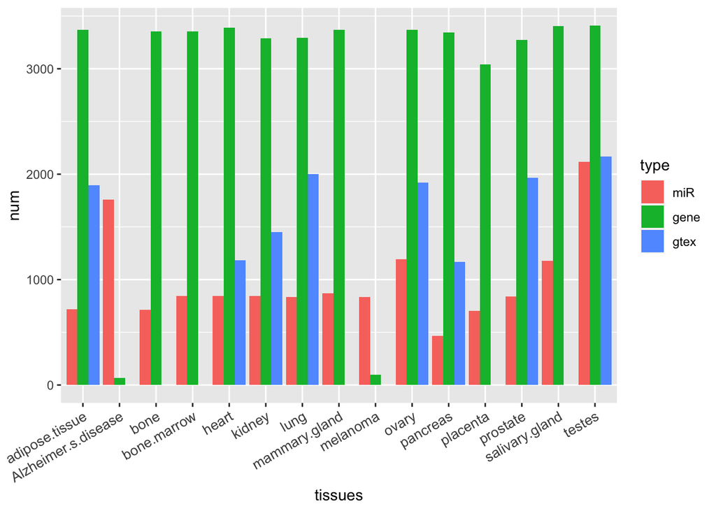

```r
tissue_table_percent_gtex <- cbind(tissue_table_percent_gtex,"type"="gtex")
colnames(tissue_table_percent_gtex)[2] <- "num"
tissue_table_percent_gtex$tissues <- c("adipose.tissue", "heart", "kidney", "lung", "ovary", "pancreas", "prostate", "testes")
tissue_table_percent_gtex <- rbind(tissue_table_percent_gtex,
                                   c("Alzheimer.s.disease", "0", "0%", "gtex"),
                                   c("bone", "0", "0%", "gtex"),
                                   c("bone.marrow", "0", "0%", "gtex"),
                                   c("mammary.gland", "0", "0%", "gtex"),
                                   c("melanoma", "0", "0%", "gtex"),
                                   c("placenta", "0", "0%", "gtex"),
                                   c("salivary.gland", "0", "0%", "gtex"))
tissue_table_percent_gtex<- tissue_table_percent_gtex[c(1, 9, 10, 11, 2, 3, 4, 12, 13, 5, 6, 14, 7, 15, 8), ]
rownames(tissue_table_percent_gtex) <- 1:nrow(tissue_table_percent_gtex)


tissue_table_percent <- rbind(tissue_table_percent, tissue_table_percent_gtex)
tissue_table_percent$num <- as.numeric(as.character(tissue_table_percent$num))

ggplot(tissue_table_percent[,c(1:4)], aes(tissues, num, fill = type)) +
  geom_bar(position="dodge", stat="identity") +
  theme(axis.text.x = element_text(angle = 30, hjust = 1, size = 10))
```

# Tissue-specific miR-gene interaction

## Process both miR and gene expression data

- The goal here is to have miR names on the first column and have the gene names on the second column. To create a similar table as the human PPI from IID.

```r
miR_expr <- read.table("/Users/helending/Documents/BCB330/mir_expr_table/data/combined_all_expr_tables.csv")
gene_expr <- read.table("/Users/helending/Documents/BCB330/mir_expr_table/data/gene_interaction_dup.csv")
for (i in 1:ncol(gene_expr)){
  gene_expr[,i]<- (as.character(gene_expr[,i]))
}
gene_expr[gene_expr == "?"] <- "10"
for (i in 2:ncol(gene_expr)){
  gene_expr[,i]<- (as.numeric(gene_expr[,i]))
}
colnames(gene_expr)[1] <- "Gene"

# query for their genes
mirs <- paste(miR_expr$miR, collapse = ", ")
length(which(as.character(mirDIP_genes$Gene.Symbol) %in% gene_expr$Gene)) # 472805
```

```r
length(gene_expr$Gene)
```

```r
length(as.character(mirDIP_genes$Gene.Symbol)) # 480650
```

```r
# genes not in IID
`%notin%` <- Negate(`%in%`)
not_in_iid <- unique(mirDIP_genes$Gene.Symbol[as.character(mirDIP_genes$Gene.Symbol) %notin% gene_expr$Gene]) # 672
length(not_in_iid)
```

```r
IID_data <- read.delim("/Users/helending/Documents/BCB330/mir_expr_table/data/human_annotated_PPIs.txt", header = TRUE, sep = "\t")

# construct a new table
final_table <- data.frame(matrix(0, nrow=nrow(mirDIP_genes), ncol=ncol(IID_data)))
colnames(final_table) <- colnames(IID_data)
colnames(final_table)[1:2] <- c("miRNA", "Gene")
final_table <- final_table[,-c(3, 4, 5, 6, 7, 8)]

final_table$miRNA <- mirDIP_genes$MicroRNA
final_table$Gene <- mirDIP_genes$Gene.Symbol

for (i in 1:ncol(final_table)){
  final_table[,i]<- as.character(final_table[,i])
}
final_table_copy <- final_table[,2:ncol(final_table)]

# order iid to be the same order
gene_expr <- gene_expr[order(match(gene_expr$Gene, final_table_copy$Gene)), ]
new <- left_join(final_table_copy, gene_expr, by=c("Gene" ="Gene"))
new <- new[, -c(2:246)]
colnames(new)[2:ncol(new)] <- colnames(IID_data)[9:ncol(IID_data)]

final_table_copy_mir <- final_table[,-2]
miR_expr <- miR_expr[order(match(final_table_copy_mir$miRNA, miR_expr$miR)), ]
colnames(miR_expr)[1] <- "miRNA"
for (i in 1:ncol(miR_expr)){
  miR_expr[,i]<- (as.character(miR_expr[,i]))
}
miR_expr[miR_expr == "?"] <- "10"
for (i in 2:ncol(miR_expr)){
  miR_expr[,i]<- (as.numeric(miR_expr[,i]))
}

new_mir <- left_join(final_table_copy_mir, miR_expr, by=c("miRNA" ="miRNA"))
new_mir <- new_mir[, -c(2:246)]
colnames(new)[2:ncol(new)] <- colnames(IID_data)[9:ncol(IID_data)]
```

## Combine the two

```r
new_mir_num <- miR_expr[,2:ncol(miR_expr)]
new_num <- new[,2:ncol(new)]

new_sum <- Reduce(`+`, lapply(list(new_mir_num, new_num),function(x) {x[is.na(x)] <-0;x}))

new_sum <- cbind(new$Gene, new_sum)
new_sum <- cbind(new_mir$miRNA, new_sum)
colnames(new_sum)[1:2] <- c("miRNA", "Gene")
```

## Assignment

After creating the final table, we assign values to them. Firsly, we know that if both are expressed, the assignment should be “1”, “0” if neither are expressed. Secondly, if one is expressed, the other is not expressed, the interaction should be assigned a “0”. If one of the expression is “?” we should assign a “?” to the pair interaction. In order to identify it easily, we assign 10 if the “?” is observed, and sum the two tables. Finally, we will assign the “0”, “1”, “?” back to them with the following rules: * 0 or 1 or 10 -> 0 * 2 -> 1 * 11 or 20 -> ?

```r
# change 10 to 0
new_sum_copy <- new_sum
new_sum_copy <- new_sum_copy[, -c(1, 2)]

new_sum_copy[new_sum_copy == 1] <- 0
new_sum_copy[new_sum_copy == 10] <- 0

new_sum_copy[new_sum_copy == 2] <- 1

for (i in 1:ncol(new_sum_copy)){
  new_sum_copy[,i]<- (as.character(new_sum_copy[,i]))
}
new_sum_copy[new_sum_copy == "11"] <- "?"
new_sum_copy[new_sum_copy == "20"] <- "?"
head(new_sum_copy)
new_sum_copy[new_sum_copy == "1"]
new_sum_copy <- cbind(new_sum$Gene, new_sum_copy)
new_sum_copy <- cbind(new_sum$miRNA, new_sum_copy)
colnames(new_sum_copy)[1:2] <- c("miRNA", "Gene")
rownames(new_sum_copy) <- 1:nrow(new_sum_copy)
write.table(new_sum_copy, "/Users/helending/Documents/BCB330/mir_gene_table/final_table.csv")
```

## Total overall analysis (all tissues) - pie chart

- The general overview of the all the tissues shows us that most of the interactions are not annotated.

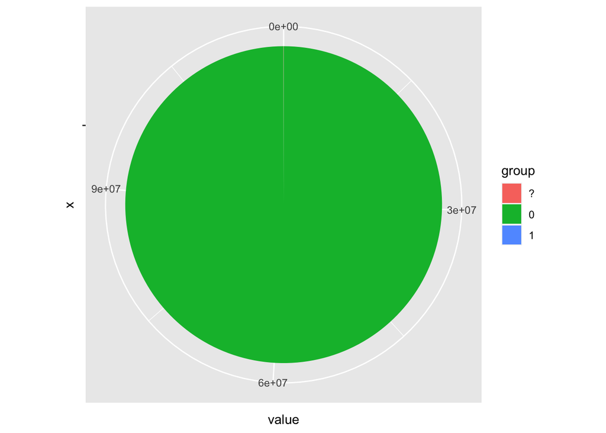

```r
final_table <- read.table("/Users/helending/Documents/BCB330/mir_gene_table/final_table.csv", stringsAsFactors = FALSE)
unknown_sum <- length(final_table[final_table == "?"]) # 35984
has_sum <- length(final_table[final_table == "1"]) # 7791
no_sum <- length(final_table[final_table == "0"]) # 117715475
df <- data.frame(
  group = c("?", "1", "0"),
  value = c(unknown_sum, has_sum, no_sum)
  )

ggplot(df, aes(x="", y=value, fill=group))+
  geom_bar(width = 1, stat = "identity")+
  coord_polar("y", start=0)
```

## Total overall analysis (15 tissues) - pie chart

- The general overview of the 15 tissues shows us that there are a little part of the data annotated.

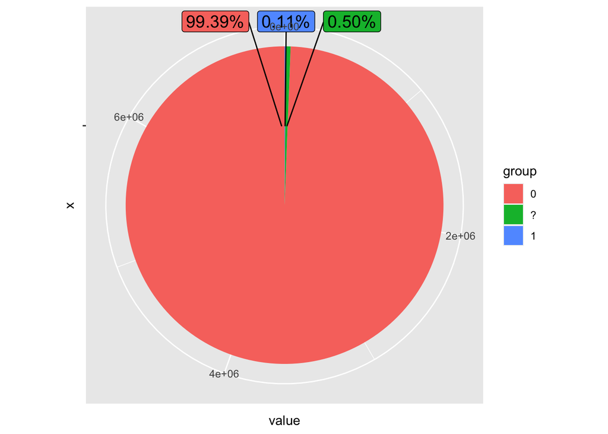

```r
final_table <- read.table("/Users/helending/Documents/BCB330/mir_gene_table/final_table.csv", stringsAsFactors = FALSE)

# which tissues do I have information in - 15
tissue_names <- character()
for (i in 1:length(new_tables_0.99)){
  tissue_names[i] <- colnames(new_tables_0.99[[i]])[2]
}

final_table_copy <- final_table[, which(colnames(final_table) %in% tissue_names)]

unknown_sum <- length(final_table_copy[final_table_copy == "?"]) # 35984
has_sum <- length(final_table_copy[final_table_copy == "1"]) # 7791
no_sum <- length(final_table_copy[final_table_copy == "0"]) # 7165975

df_final <- data.frame(
  group = c("?", "1", "0"),
  value = c(unknown_sum, has_sum, no_sum)
  )

df_final %>%
arrange(desc(value)) %>%
mutate(prop = percent(value / sum(value))) -> mydf_final

ggplot(mydf_final, aes(x = "", y = value, fill = fct_inorder(group))) +
       geom_bar(width = 1, stat = "identity") +
       coord_polar("y", start = 0) +
       geom_label_repel(aes(label = prop), size=5, show.legend = F, nudge_x = 1) +
       guides(fill = guide_legend(title = "group"))
```

## Analysis of miRNA-gene interactions

```r
final_table <- read.table("/Users/helending/Documents/BCB330/mir_gene_table/final_table.csv", stringsAsFactors = FALSE)

# which tissues do I have information in - 15
tissue_names <- character()
for (i in 1:length(new_tables_0.99)){
  tissue_names[i] <- colnames(new_tables_0.99[[i]])[2]
}

final_table_copy <- final_table[,which(colnames(final_table) %in% tissue_names)]
```

### miRNA-gene interaction analysis (number 1)

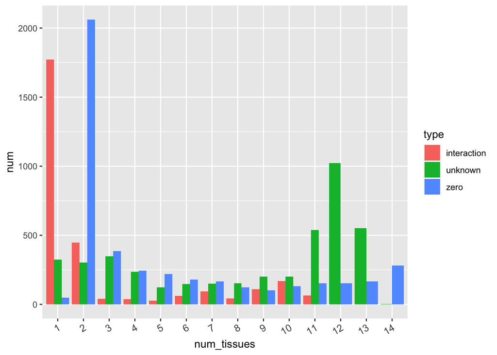

```r
# add a column
final_table_copy_col <- cbind(final_table_copy,
                              "num_tissue" = rowSums(final_table_copy == "1"),
                              "num_unknown" = rowSums(final_table_copy == "?"),
                              "num_zero" = rowSums(final_table_copy == "0"))

num_tissue_table <- data.frame(table(final_table_copy_col$num_tissue))
colnames(num_tissue_table) <- c("num_tissues", "num")
num_tissue_table$type <- "interaction"

num_unknown_table <- data.frame(table(final_table_copy_col$num_unknown))
colnames(num_unknown_table) <- c("num_tissues", "num")
num_unknown_table$type <- "unknown"

num_zero_table <- data.frame(table(final_table_copy_col$num_zero))
colnames(num_zero_table) <- c("num_tissues", "num")
num_zero_table$type <- "zero"

# combine the three tables
num_two_table <- rbind(num_unknown_table, num_tissue_table)
num_three_table <- rbind(num_two_table, num_zero_table)

# so many 0s, do not consider them
num_three_table <- num_three_table[-which(num_three_table$num_tissues == 0), ]
num_three_table <- num_three_table[-nrow(num_three_table), ]

# graph
ggplot(num_three_table, aes(num_tissues, num, fill = type)) +
  geom_bar(position="dodge", stat="identity") +
  theme(axis.text.x = element_text(angle = 30, hjust = 1, size = 10))
```

### miRNA-gene interaction analysis (number 2)

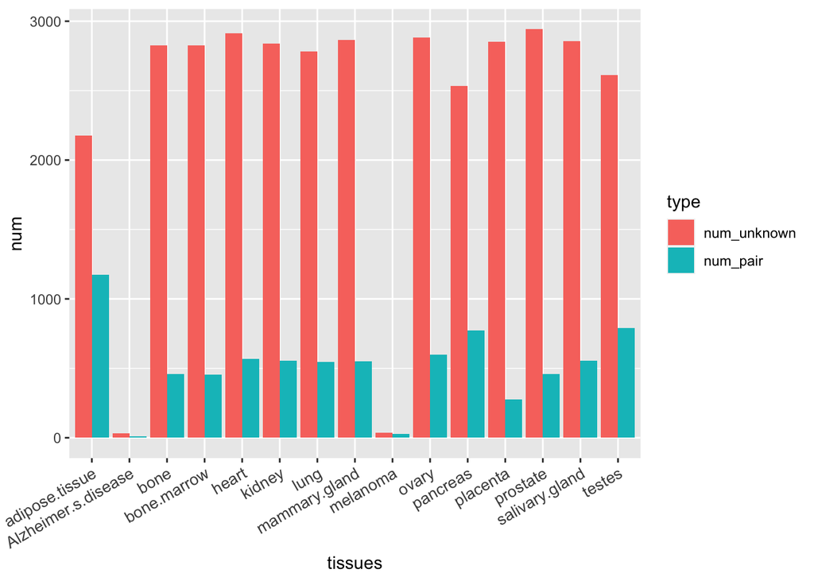

```r
# ==== add a row ====
final_table_copy_row <- rbind(final_table_copy,
                              colSums(final_table_copy == "1"),
                              colSums(final_table_copy == "?"),
                              colSums(final_table_copy == "0"))
# graph table
tissue_table <- data.frame("tissues"=colnames(final_table_copy_row)[1:ncol(final_table_copy_row)],
                           "num"=as.numeric(final_table_copy_row[nrow(final_table_copy_row)-2,]),
                           "type"= "num_pair")

tissue_unknown_table <- data.frame("tissues"=colnames(final_table_copy_row)[1:ncol(final_table_copy_row)],
                           "num"=as.numeric(final_table_copy_row[nrow(final_table_copy_row)-1,]),
                           "type"= "num_unknown")

tissue_zero_table <- data.frame("tissues"=colnames(final_table_copy_row)[1:ncol(final_table_copy_row)],
                           "num"=as.numeric(final_table_copy_row[nrow(final_table_copy_row), ]),
                           "type"= "num_zero")

tissue_two_table <- rbind(tissue_unknown_table, tissue_table)
tissue_three_table <- rbind(tissue_two_table, tissue_zero_table)

# graph
ggplot(tissue_two_table, aes(tissues, num, fill = type)) +
  geom_bar(position="dodge", stat="identity") +
  theme(axis.text.x = element_text(angle = 30, hjust = 1, size = 10))
```

# References

Haunsberger, Stefan J, Niamh M C Connolly, and Jochen H M Prehn. 2016. “miRNAmeConverter: An R/Bioconductor Package for Translating Mature miRNA Names to Different miRBase Versions.” *Bioinformatics*. https://doi.org/10.1093/bioinformatics/btw660.

Kassambara, Alboukadel. 2020. *Ggpubr: ’Ggplot2’ Based Publication Ready Plots*. https://CRAN.R-project.org/package=ggpubr.

Kotlyar, Max, Chiara Pastrello, Zara Malik, and Igor Jurisica. 2019. “IID 2018 Update: Context-Specific Physical Protein–Protein Interactions in Human, Model Organisms and Domesticated Species.” *Nucleic Acids Research* 47 (D1). Oxford University Press: D581–D589.

Slowikowski, Kamil. 2020. *Ggrepel: Automatically Position Non-Overlapping Text Labels with ’Ggplot2’*. https://CRAN.R-project.org/package=ggrepel.

Steffen Durinck, Ewan Birney, Paul T. Spellman, and Wolfgang Huber. 2009. “Mapping Identifiers for the Integration of Genomic Datasets with the R/Bioconductor Package biomaRt.” *Nature Protocols* 4: 1184–91.

Waldron, Levi, and Markus Riester. 2019. *HGNChelper: Identify and Correct Invalid Hgnc Human Gene Symbols and Mgi Mouse Gene Symbols*. https://CRAN.R-project.org/package=HGNChelper.

Wickham, Hadley. 2016. *Ggplot2: Elegant Graphics for Data Analysis*. Springer-Verlag New York. https://ggplot2.tidyverse.org.

———. 2019. *Httr: Tools for Working with Urls and Http*. https://CRAN.R-project.org/package=httr.

———. 2020. *Forcats: Tools for Working with Categorical Variables (Factors)*. https://CRAN.R-project.org/package=forcats.

Wickham, Hadley, Mara Averick, Jennifer Bryan, Winston Chang, Lucy D’Agostino McGowan, Romain François, Garrett Grolemund, et al. 2019. “Welcome to the tidyverse.” *Journal of Open Source Software* 4 (43): 1686. https://doi.org/10.21105/joss.01686.

Wickham, Hadley, Romain François, Lionel Henry, and Kirill Müller. 2020. *Dplyr: A Grammar of Data Manipulation*. https://CRAN.R-project.org/package=dplyr.

Wickham, Hadley, and Dana Seidel. 2019. *Scales: Scale Functions for Visualization*. https://CRAN.R-project.org/package=scales.

Zhu, Hao. 2019. *KableExtra: Construct Complex Table with ’Kable’ and Pipe Syntax*. https://CRAN.R-project.org/package=kableExtra.